# Statistics and Predictive Analytics, Lab 4

Swati Singh

### Introduction

This lab will give you practice with some of the topics we have been discussing recently:

- Inspecting and cleaning data.
- Imputing missing data.
- Estimating out of sample model performance.

The dataset for the lab, “wage.csv,” is available on Canvas (in the Data folder) and consists in wage data on workers in the Mid Atlantic region in the early 2000s. The outcome variable for the analysis is wage, which represents an individual’s earnings measured in $1000s. Our aim will be to build a regression model of wage.

### Data inspection and cleaning

The dataset is pretty messy. We can see that there are 10 variables that could be used to predict worker wages, some of which have missing observations, and some of which will not be helpful in the analysis. Let’s start out by doing some EDA to understand the dataset.

**Question 1**: Summarize the data and think about how you’ll build a model. Which variables, for example, will NOT be helpful in modeling wage? Explain your answer.

`r`r # Your code goes here summary(w)

```
      year           age             sex                    maritl           race
 Min.   :2003   Min.   :18.00   1. Male:3002   1. Never Married: 603   1. White:2442
 1st Qu.:2004   1st Qu.:34.00                  2. Married      :2055   2. Black: 291
 Median :2006   Median :43.00                  3. Widowed      :  19   3. Asian: 187
 Mean   :2006   Mean   :42.75                  4. Divorced     : 204   4. Other:  36
 3rd Qu.:2008   3rd Qu.:51.00                  5. Separated    :  57   NA's    :  46
 Max.   :2009   Max.   :80.00                  NA's            :  64
 NA's   :75     NA's   :58
              education                  region               jobclass               health
 1. < HS Grad      :258   2. Middle Atlantic:3002   1. Industrial :1491   1. <=Good     : 842
 2. HS Grad        :950                             2. Information:1458   2. >=Very Good:2110
 3. Some College   :635                             NA's          :  53   NA's          :  50
 4. College Grad   :676
 5. Advanced Degree:425
 NA's              : 58

  health_ins        wage
 1. Yes:2054   Min.   :     -2
 2. No : 890   1st Qu.:     85
 NA's  :  58   Median :    105
               Mean   :   2443
               3rd Qu.:    129
               Max.   :7000000
```

`r`r dim(w)

```
[1] 3002   11
```

> First look at the summary of the data exposes two variables, Sex and Region that have only one factor level. Sex covers wages of only male employees. Also wages are covered for Middle Atlantic region only.

It should have been clear from your data inspection that the outcome variable, wage, needs some work. In the lecture videos I made the point that outliers should not be removed if they are legitimately part of your sample but *should* be removed if, for example, they are out of the variable’s logical range. In this case we would want to classify them not as *outliers* but as *mistakes*. For example, in the bike ridership data, if an observation had a value of 13 for month—an impossible value—it should be classified as a coding error and either removed or, based on available clues, changed.

**Queston 2**: Take a close look at wage. There are errors. (Remember that wage is expressed in $1000s.) How should it be cleaned? How many rows are left in the dataset after this cleaning?

`r`r # Your code goes here w[,c(‘sex’,‘region’)]<-NULL summary(w)

```
      year           age                     maritl           race                   education
 Min.   :2003   Min.   :18.00   1. Never Married: 603   1. White:2442   1. < HS Grad      :258
 1st Qu.:2004   1st Qu.:34.00   2. Married      :2055   2. Black: 291   2. HS Grad        :950
 Median :2006   Median :43.00   3. Widowed      :  19   3. Asian: 187   3. Some College   :635
 Mean   :2006   Mean   :42.75   4. Divorced     : 204   4. Other:  36   4. College Grad   :676
 3rd Qu.:2008   3rd Qu.:51.00   5. Separated    :  57   NA's    :  46   5. Advanced Degree:425
 Max.   :2009   Max.   :80.00   NA's            :  64                   NA's              : 58
 NA's   :75     NA's   :58
           jobclass               health      health_ins        wage
 1. Industrial :1491   1. <=Good     : 842   1. Yes:2054   Min.   :     -2
 2. Information:1458   2. >=Very Good:2110   2. No : 890   1st Qu.:     85
 NA's          :  53   NA's          :  50   NA's  :  58   Median :    105
                                                           Mean   :   2443
                                                           3rd Qu.:    129
                                                           Max.   :7000000
```

```
Deprecated, use tibble::rownames_to_column() instead.
```

| year | age | maritl | race | education | jobclass | health | health_ins | wage |
| --- | --- | --- | --- | --- | --- | --- | --- | --- |
| 2004 | 33 | 5. Separated | 2. Black | 3. Some College | 2. Information | 2. >=Very Good | 1. Yes | -1.98e+00 |
| 2004 | 33 | 5. Separated | 2. Black | 3. Some College | 2. Information | 2. >=Very Good | 1. Yes | 7.00e+06 |

`r`r w<-w %>% filter(wage>0 & wage<2500) dim(w)

```
[1] 3000    9
```

[output not shown]

Following Lab 3’s focus on log transformation, we should also ask whether it would make sense to log transform wage for this analysis. If wage’s distribution is skewed and/or has a large range then it might be a good candidate for log transformation.

**Question 3**: Create two histograms, one of the unlogged wage variable and one of the logged wage variable, using the cleaned dataset. Create and label vertical lines representing the mean and median of each variable. Produce titles for each plot. Comment on what you see.

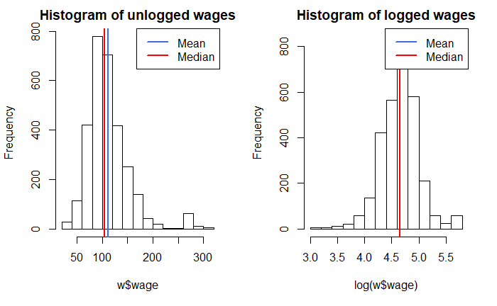

> The distribution of wages is right skewed. The mean is skewed towards higher wages.The median can be used as a measure of central tendency. The logged wages histogram is more normally distributed and will be a better candidate to use in our prediction model. The mean and median of the logged wags overlap each other.

[output not shown]

`r`r summary(lm(wage~.,w))

```
Call:
lm(formula = wage ~ ., data = w)

Residuals:
     Min       1Q   Median       3Q      Max
-100.944  -19.558   -3.342   13.614  212.316

Coefficients:
                              Estimate Std. Error t value Pr(>|t|)
(Intercept)                 -2.469e+03  6.574e+02  -3.756 0.000176 ***
year                         1.265e+00  3.278e-01   3.860 0.000116 ***
age                          2.086e-01  6.834e-02   3.053 0.002289 **
maritl2. Married             1.771e+01  1.914e+00   9.252  < 2e-16 ***
maritl3. Widowed             2.742e+00  8.229e+00   0.333 0.739029
maritl4. Divorced            4.577e+00  3.055e+00   1.498 0.134171
maritl5. Separated           1.193e+01  5.097e+00   2.340 0.019354 *
race2. Black                -5.394e+00  2.254e+00  -2.392 0.016805 *
race3. Asian                -2.834e+00  2.758e+00  -1.028 0.304253
race4. Other                -8.201e+00  6.445e+00  -1.272 0.203345
education2. HS Grad          8.062e+00  2.598e+00   3.103 0.001933 **
education3. Some College     1.944e+01  2.757e+00   7.051 2.24e-12 ***
education4. College Grad     3.219e+01  2.757e+00  11.676  < 2e-16 ***
education5. Advanced Degree  5.461e+01  2.999e+00  18.209  < 2e-16 ***
jobclass2. Information       2.729e+00  1.405e+00   1.943 0.052179 .
health2. >=Very Good         6.860e+00  1.519e+00   4.516 6.58e-06 ***
health_ins2. No             -1.794e+01  1.514e+00 -11.852  < 2e-16 ***
---
Signif. codes:  0 â€˜***â€™ 0.001 â€˜**â€™ 0.01 â€˜*â€™ 0.05 â€˜.â€™ 0.1 â€˜ â€™ 1

Residual standard error: 34.83 on 2743 degrees of freedom
  (240 observations deleted due to missingness)
Multiple R-squared:  0.317, Adjusted R-squared:  0.313
F-statistic: 79.56 on 16 and 2743 DF,  p-value: < 2.2e-16
```

`r`r summary(lm(log(wage)~.,w))

```
Call:
lm(formula = log(wage) ~ ., data = w)

Residuals:
     Min       1Q   Median       3Q      Max
-1.52920 -0.14961  0.00407  0.15457  1.23186

Coefficients:
                              Estimate Std. Error t value Pr(>|t|)
(Intercept)                 -2.162e+01  5.258e+00  -4.112 4.04e-05 ***
year                         1.292e-02  2.622e-03   4.926 8.88e-07 ***
age                          1.684e-03  5.466e-04   3.080  0.00209 **
maritl2. Married             1.666e-01  1.531e-02  10.883  < 2e-16 ***
maritl3. Widowed             5.350e-02  6.582e-02   0.813  0.41634
maritl4. Divorced            4.953e-02  2.444e-02   2.027  0.04275 *
maritl5. Separated           1.223e-01  4.076e-02   3.001  0.00271 **
race2. Black                -4.484e-02  1.803e-02  -2.486  0.01296 *
race3. Asian                -2.162e-02  2.206e-02  -0.980  0.32704
race4. Other                -8.097e-02  5.155e-02  -1.571  0.11638
education2. HS Grad          8.221e-02  2.078e-02   3.957 7.79e-05 ***
education3. Some College     1.910e-01  2.205e-02   8.661  < 2e-16 ***
education4. College Grad     2.872e-01  2.205e-02  13.024  < 2e-16 ***
education5. Advanced Degree  4.357e-01  2.399e-02  18.166  < 2e-16 ***
jobclass2. Information       1.589e-02  1.123e-02   1.415  0.15727
health2. >=Very Good         6.064e-02  1.215e-02   4.991 6.39e-07 ***
health_ins2. No             -1.928e-01  1.211e-02 -15.925  < 2e-16 ***
---
Signif. codes:  0 â€˜***â€™ 0.001 â€˜**â€™ 0.01 â€˜*â€™ 0.05 â€˜.â€™ 0.1 â€˜ â€™ 1

Residual standard error: 0.2786 on 2743 degrees of freedom
  (240 observations deleted due to missingness)
Multiple R-squared:  0.352, Adjusted R-squared:  0.3482
F-statistic: 93.13 on 16 and 2743 DF,  p-value: < 2.2e-16
```

`r`r #R-squared improves slightly for the logged wages model.

This wouldn’t prevent the model from fitting but it could influence results since the missing observations might not be missing completely at random (MCAR). For example, suppose that all the NAs came from low education workers who also happen to have low wages. Such a pattern, known as missing at random (MAR), would bias the relationship between education and wages since only the low education *high* wage workers are left in the dataset. In practice it can be difficult or impossible to know whether missing observations are MCAR or just MAR. Best to treat them as MAR and impute. If we know that the observations *are* missing completely at random then, in theory, the missing observations could be removed without creating bias in our models.

So, the next stage in cleaning is to impute missing observations. There are a variety of possibilities for imputation.

1. We could use the column vector’s median or mean. The mean can be problematic if the data is skewed, which is why the preferred value for imputation is usually the median.
2. Alternatively, we could use a multivariable model to predict the missings in a column, with information from the other columns as inputs. This can be very slow, however, if the dataset is large. Imputation with medians or means is always very quick.

In this lab we will do model-based imputation using the missForest package, relying on all the default settings. Note that because missForest includes a random process, it will be essential to set the seed, as I have done in the code chunk. After loading the package simply use the `missforest()` function. Here is an example using the Boston dataset:

`r`r # data(Boston) # # set.seed(222) # b <- cbind(medv = Boston$medv, prodNA(Boston[,-14], .5)) # # Note: this is code just to produce NAs so that we can later impute them # # summary(b) # Many missings! # # # Now run missForest. Need to set seed. # set.seed(222) # missForest(b)$ximp %>% # glimpse # Look at just the top rows

`r`r # b$chas <- factor(b$chas) # Factor # # set.seed(222) # impb <- missForest(b)$ximp # Impute # # glimpse(impb) #Inspect

We are in a position now, having introduced the NAs into the Boston dataset, to compare the imputations with ground truth.

`r`r # mean(Boston$crim); mean(impb$crim) # mean(Boston$zn); mean(impb$zn) # mean(Boston$indus); mean(impb$indus) # mean(Boston$chas); mean(as.numeric(as.character(impb$chas))) # mean(Boston$nox); mean(impb$nox) # mean(Boston$rm); mean(impb$rm) # mean(Boston$age); mean(impb$age) # mean(Boston$dis); mean(impb$dis) # mean(Boston$rad); mean(impb$rad) # mean(Boston$tax); mean(impb$tax) # mean(Boston$ptratio); mean(impb$ptratio) # mean(Boston$black); mean(impb$black) # mean(Boston$lstat); mean(impb$lstat)

**Question 4**: Go ahead and impute missing observations in the wage dataset. For the same reason that we factored chas above, you will want to factor year in the wage dataset, at least for imputation. You can change it back to an integer variable later. Remember to use set.seed() before using missForest. Throughout this lab, we will use the same arbitrary seed: 222.

`r`r #Your code goes here. set.seed(222) w$year <- as.factor(w$year) # Factor year w <- missForest(w)$ximp # Impute with missForest and assign result

```
  missForest iteration 1 in progress...done!
  missForest iteration 2 in progress...done!
  missForest iteration 3 in progress...done!
  missForest iteration 4 in progress...done!
  missForest iteration 5 in progress...done!
  missForest iteration 6 in progress...done!
  missForest iteration 7 in progress...done!
  missForest iteration 8 in progress...done!
  missForest iteration 9 in progress...done!
  missForest iteration 10 in progress...done!
```

### Modeling and cross-validation

**Question 5**: In preparation for modeling, create 30% test and 70% train datasets. Example code for doing this is in the tutorial scripts. There are multiple methods. (I prefer the createDataPartition() function in caret, which ensures balance between variables in test and train sets.) Note that because the split is random we need to set the seed. Even with the same seed, however, different methods will return different results. How do you know if you did this correctly? Your train set should have .7 * 3000 rows, and your test should have the remainder. Remember to use set.seed()!

`r`r # Your code goes here set.seed(222) trainIndex <- createDataPartition(w$wage, p = .7, list = FALSE) wTrain <- w[trainIndex,] wTest <- w[-trainIndex,] dim(wTrain)

```
[1] 2102    9
```

`r`r .7*3000

```
[1] 2100
```

`r`r nrow(na.omit(wTrain))

```
[1] 2102
```

We will use the train dataset to fit a model, and evaluate its performance on the test dataset.

**Question 6**: Explain why we would use a test dataset to evaluate model performance.

> Ideally, the model should be evaluated on samples that were not used to build or fine-tune the model, so that they provide an unbiased sense of model effectiveness. When a large amount of data is at hand, a set of samples can be set aside to evaluate the final model. The “training” data set is the general term for the samples used to create the model, while the “test” or “validation” data set is used to qualify performance. A test set is a single evaluation of the model and has limited ability to characterize the uncertainty in the results.Proportionally large test sets divide the data in a way that increases bias in the performance estimates. It is desirable to have low bias and variance properties of the performance estimate. Hence we use k-fold cross validation.- Max Kuhn and Kjell Johnson, Page 67-78, Applied Predictive Modeling, 2013.

**Question 7**: Using the test dataset, estimate the out-of-sample performance of a model of wage that uses all predictors. Use wage, not log wage, as the outcome in this model, and make sure to turn year back into an integer.

Why do we want year as a number rather than a factor? The result of subtracting one year from another makes sense as a number, and coding the variable as a number creates a model that is more robust to overfitting because there are fewer parameters. To convert a factor into a number is a little cumbersome in R. First turn the factor into a character with as.character(), then turn the resulting character variable into a number with as.numeric().

```
RMSE of out-of-sample- test set:  32.21126
```

> The RMSE is 32.21

**Question 8**: Using the caret package, estimate out of sample performance for the above model (all predictors, unlogged wage) using repeated 10-fold cross-validation (repeat 10 times), but use the entire dataset. Remember that you should use set.seed() to control randomness in caret’s cross validation procedure. Report estimated out-of-sample RMSE and $R^2$ and compare it to in-sample RMSE and $R^2$. Comment on whether this model seems to be overfitting. And, as above, convert year again to a number.

[output not shown]

|  | RMSE | Rsquared |
| --- | --- | --- |
| 1 | 33.89358 | 0.3406775 |

> Out-of-sample RMSE: 33.89, R-squared: 0.34 In-sample RMSE: 33.80, R-squared 0.34 We can see that the RMSE for out-of-sample and in-sample performance are almost the same. So we can say that this model is not overfitting.